### Activity Monitoring Project

**Loading and Preprocessing the Data**

The data for the project was provided in a .zip file. The first step was to extract the file activity.csv.

The data was then read into an R data frame using the following code.

```r
df <- read.csv("activity.csv")
```

**What is mean total number of steps taken per day?**

The total number of steps per day was calculated using the following code.

```r
library(tidyverse)
```

```r
steps_per_day <- df %>% group_by(date) %>%
    summarize(Steps = sum(steps))
print(steps_per_day,n = nrow(steps_per_day))
```

```
## # A tibble: 61 x 2
##    date       Steps
##    <fct>      <int>
##  1 2012-10-01    NA
##  2 2012-10-02   126
##  3 2012-10-03 11352
##  4 2012-10-04 12116
##  5 2012-10-05 13294
##  6 2012-10-06 15420
##  7 2012-10-07 11015
##  8 2012-10-08    NA
##  9 2012-10-09 12811
## 10 2012-10-10  9900
## 11 2012-10-11 10304
## 12 2012-10-12 17382
```

[output cut: 49 more lines]

Below is a histogram of the steps per day showing the frequency of the number of steps. This code was used to create the histogram.

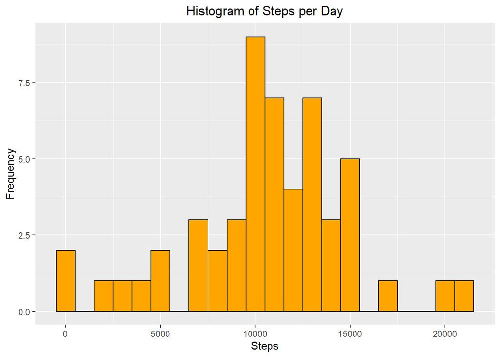

```r
steps_per_day %>% ggplot(aes(Steps)) +
    geom_histogram(binwidth = 1000, col = "Black", fill = "Orange") +
    ggtitle("Histogram of Steps per Day") + ylab("Frequency") +
    theme(plot.title = element_text(hjust = 0.5))
```

The mean steps per day and the median steps per day were calculated using the following code.

```r
mean_steps_per_day <- steps_per_day %>% summarize(mean = mean(Steps, na.rm = TRUE))
mean_steps_per_day
```

```
## # A tibble: 1 x 1
##     mean
##    <dbl>
## 1 10766.
```

```r
median_steps_per_day <- steps_per_day %>% summarize(median = median(Steps,na.rm = TRUE))
median_steps_per_day
```

```
## # A tibble: 1 x 1
##   median
##    <int>
## 1  10765
```

**What is the average daily activity pattern?**

The following time series plot shows the average number of steps taken per 5 minute interval.

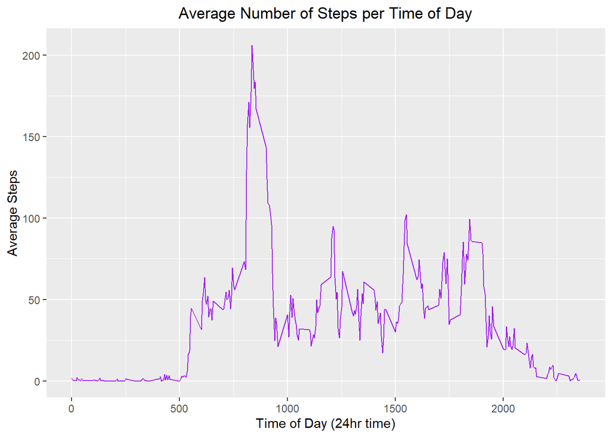

```r
avg <- df %>% group_by(interval) %>% summarize(Mean = mean(steps, na.rm = TRUE))
avg %>% ggplot(aes(interval, Mean)) +
    geom_line(col = "Purple") +
    xlab("Time of Day (24hr time)") +
    ylab("Average Steps") +
    ggtitle("Average Number of Steps per Time of Day") +
    theme(plot.title = element_text(hjust = 0.5))
```

The maximum average number of steps was determined using the following code.

```r
max(avg$Mean)
```

```
## [1] 206.1698
```

The interval with the maximum number of steps was determined using the code below.

```r
avg$interval[which(avg$Mean == max(avg$Mean))]
```

```
## [1] 835
```

**Imputing missing values**

The total number of rows with missing steps data is calculated using the following code.

```r
sum(is.na(df$steps))
```

```
## [1] 2304
```

The following code replaces the NAs in the datawith the average of the appropriate 5 minute interval.

```r
df1 <- transform(df, steps = ifelse(is.na(steps), avg$Mean,steps))
```

The following is a histogram of steps per day

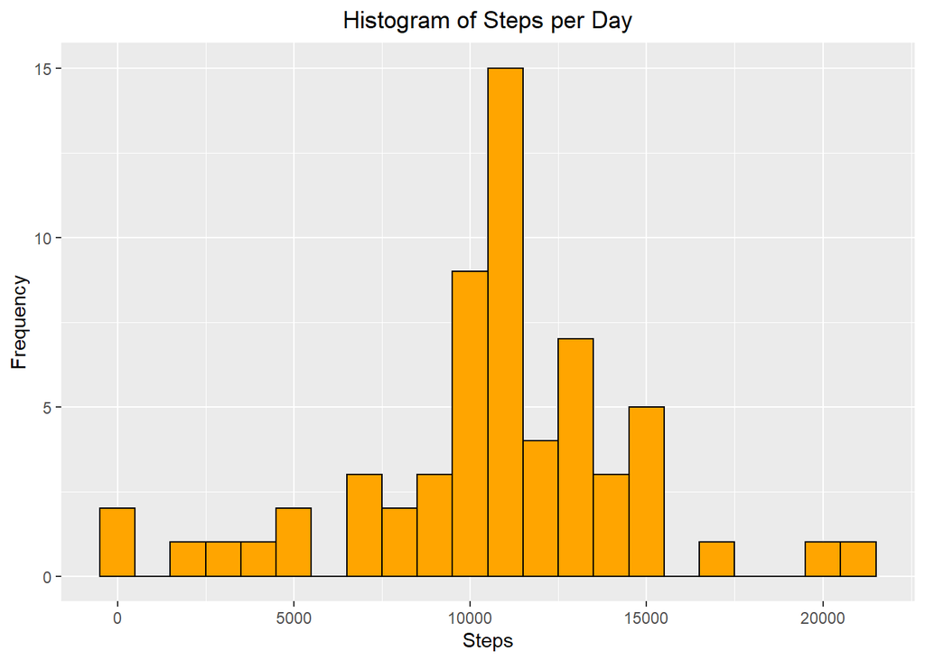

```r
steps_per_day <- df1 %>% group_by(date) %>%
    summarize(Steps = sum(steps))
steps_per_day %>% ggplot(aes(Steps)) +
    geom_histogram(binwidth = 1000, col = "Black", fill = "Orange") +
    ggtitle("Histogram of Steps per Day") + ylab("Frequency") +
    theme(plot.title = element_text(hjust = 0.5))
```

The mean steps per day and the median steps per day, with imputed NAs, were calculated using the following code.

```r
mean_steps_per_day <- steps_per_day %>% summarize(mean = mean(Steps, na.rm = TRUE))
mean_steps_per_day
```

```
## # A tibble: 1 x 1
##     mean
##    <dbl>
## 1 10766.
```

```r
median_steps_per_day <- steps_per_day %>% summarize(median = median(Steps,na.rm = TRUE))
median_steps_per_day
```

```
## # A tibble: 1 x 1
##   median
##    <dbl>
## 1 10766.
```

Based on these numbers, imputing the NA values did not impact the mean or median values very much.

**Are there differences in activity patterns between weekdays and weekends?**

A new factor variable was added to the data frame characterizing the day as a weekday or the weekend.

```r
df1$date <- as.Date(df1$date)
df1$day <- ifelse(weekdays(df1$date) == "Saturday" | weekdays(df1$date) == "Sunday", "weekend", "weekday")
```

A panel plot was created showing the average steps per time of day for weekdays and weekends using the following code.

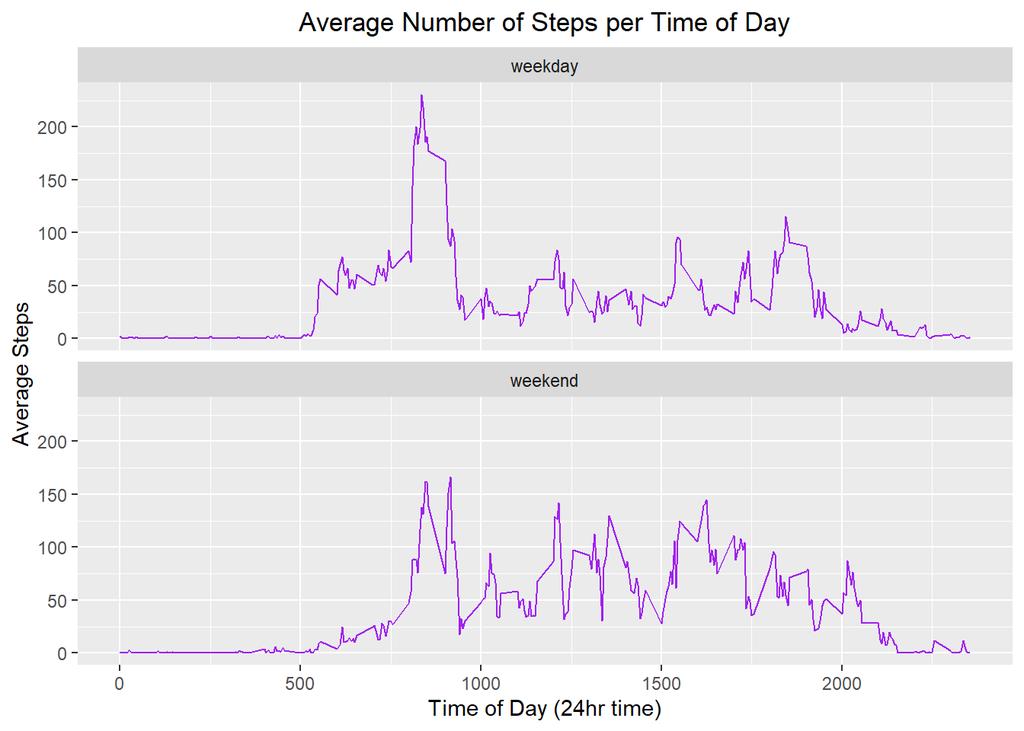

```r
avg1 <- df1 %>% group_by(interval, day) %>% summarize(Mean = mean(steps, na.rm = TRUE))
avg1 %>% ggplot(aes(interval, Mean)) +
    geom_line(col = "Purple") +
    facet_wrap(vars(day),nrow = 2) +
    xlab("Time of Day (24hr time)") +
    ylab("Average Steps") +
    ggtitle("Average Number of Steps per Time of Day") +
    theme(plot.title = element_text(hjust = 0.5))
```